# DSSS2022 Machine Learning in R: Task List 06

Goran S. Milovanovic, DataKolektiv

[figure not shown]

# Regularized GLMs

Again we will be using the `glmnet` package: `install.packages("glmnet")`

```r
library(tidyverse)
library(glmnet)
library(car)
data_dir <- paste0(getwd(), "/_data/")
```

### Task 01

We will now work on a rather well-know multiclass (or regression) problem represented by the [wine-quality(https://archive.ics.uci.edu/ml/machine-learning-databases/wine-quality/) dataset in the [UCI Machine Learning repository](https://archive.ics.uci.edu/ml/index.php). You will need to access the red wine quality dataset (`winequality-red.csv`).

```r
data_set <- read.csv(paste0(data_dir, "winequality-red.csv"),
                     header = TRUE,
                     sep = ";",
                     check.names = FALSE,
                     stringsAsFactors = FALSE)
head(data_set)
```

|  | fixed acidity | volatile acidity | citric acid | residual sugar | chlorides | free sulfur dioxide | total sulfur dioxide | density | pH | sulphates | alcohol | quality |
| --- | --- | --- | --- | --- | --- | --- | --- | --- | --- | --- | --- | --- |
| 1 | 7.4 | 0.70 | 0.00 | 1.9 | 0.076 | 11 | 34 | 0.9978 | 3.51 | 0.56 | 9.4 | 5 |
| 2 | 7.8 | 0.88 | 0.00 | 2.6 | 0.098 | 25 | 67 | 0.9968 | 3.20 | 0.68 | 9.8 | 5 |
| 3 | 7.8 | 0.76 | 0.04 | 2.3 | 0.092 | 15 | 54 | 0.9970 | 3.26 | 0.65 | 9.8 | 5 |
| 4 | 11.2 | 0.28 | 0.56 | 1.9 | 0.075 | 17 | 60 | 0.9980 | 3.16 | 0.58 | 9.8 | 6 |
| 5 | 7.4 | 0.70 | 0.00 | 1.9 | 0.076 | 11 | 34 | 0.9978 | 3.51 | 0.56 | 9.4 | 5 |
| 6 | 7.4 | 0.66 | 0.00 | 1.8 | 0.075 | 13 | 40 | 0.9978 | 3.51 | 0.56 | 9.4 | 5 |

The goal of the exercise is to train a regularized Multinomial Regression model to predict the quality class:

```r
data_set$quality <- factor(data_set$quality,
                           levels = c(3, 4, 5, 6, 7, 8))
table(data_set$quality)
```

```
  3   4   5   6   7   8
 10  53 681 638 199  18
```

To specify a Multinomial Regression model in `glmnet`, you will need to use: `family="multinomial"`.

Please perform both LASSO (alpha = 1, which is the `glmnet` default) and Ridge (alpha = 0) regressions.

Compare the results and make sure that you understand the interpretation of regression coefficients in Multinomial Regression. Why does `plot(glmnet_mnr, label = TRUE)` return several plots?

#### LASSO

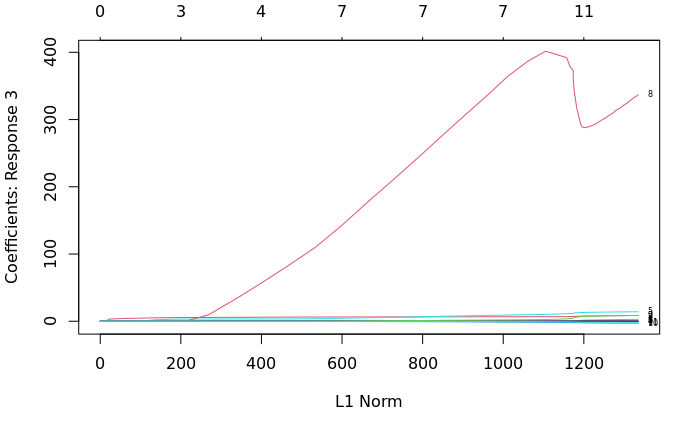

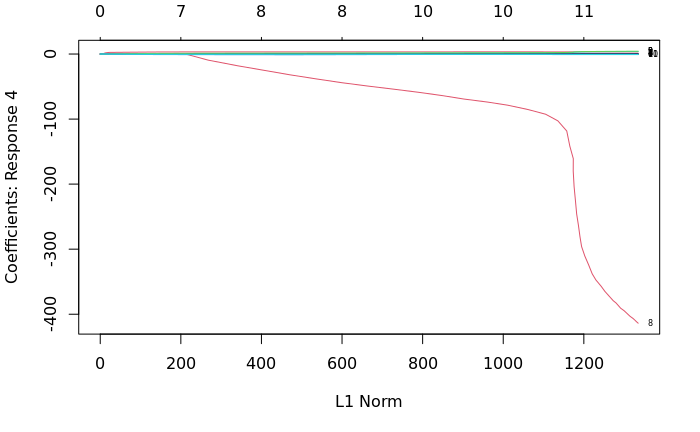

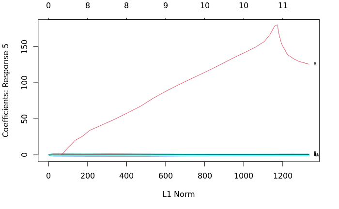

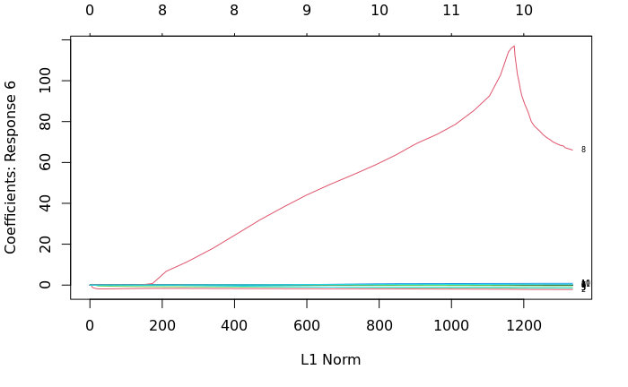

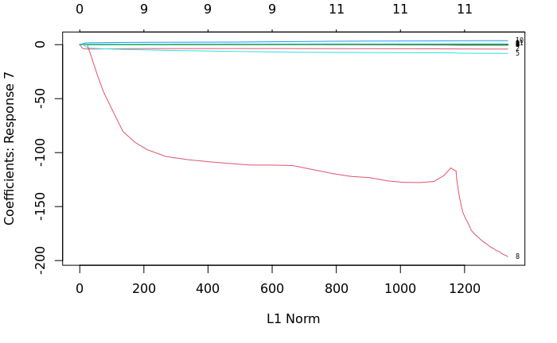

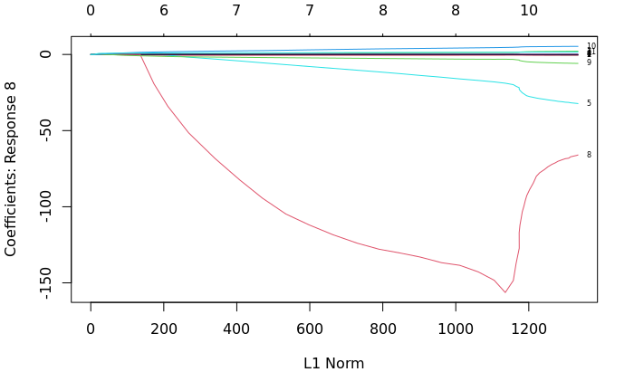

```r
X <- data_set %>% select(-quality)
y <- data_set$quality
glmnet_mnr <- glmnet(x = X, y = y,
                     alpha = 1,
                     family = "multinomial")
plot(glmnet_mnr, label = TRUE)
```

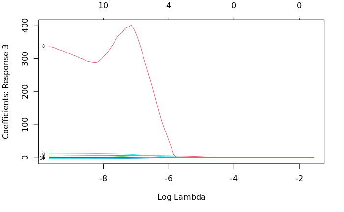

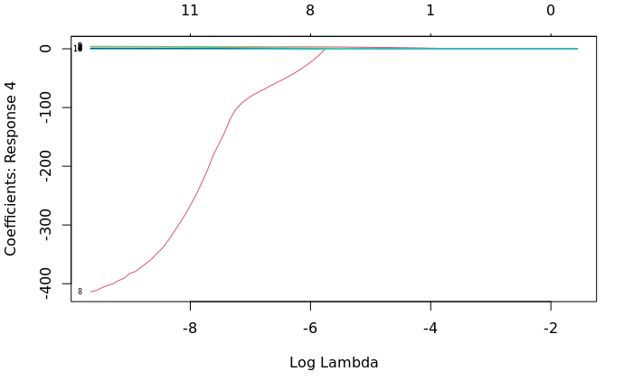

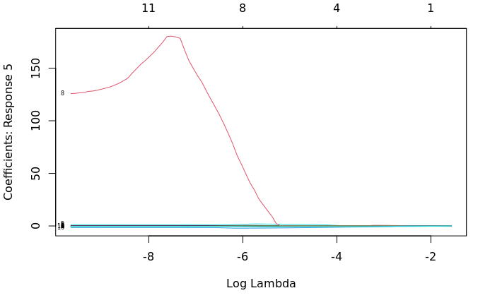

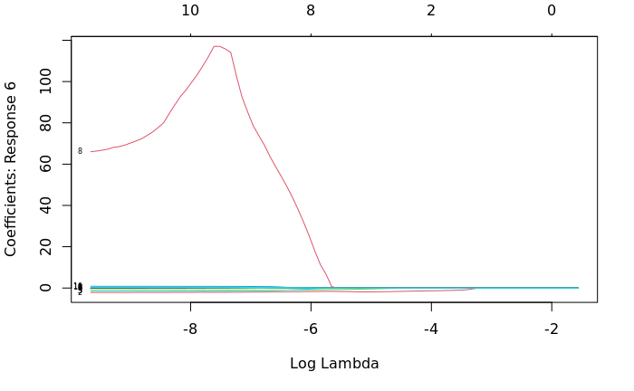

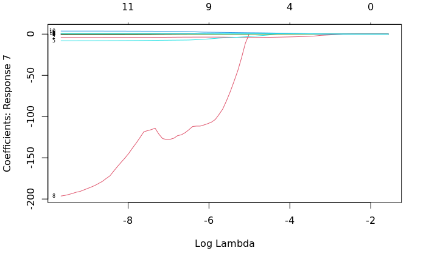

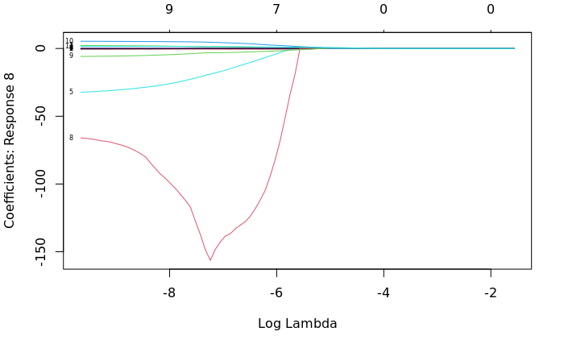

```r
plot(glmnet_mnr, label = TRUE, xvar = "lambda")
```

The $\lambda$ value of the best model found **without CV**:

```r
w_best <- which.min(deviance(glmnet_mnr))
best_lambda <- glmnet_mnr$lambda[w_best]
print(best_lambda)
```

```
[1] 6.388409e-05
```

Re-fit the best model:

```r
glmnet_mnr_best <- glmnet(x = X, y = y,
                          alpha = 1,
                          lambda = best_lambda,
                          family = "multinomial")
```

Coefficients (carefully - we have a set of coefficients for each class):

```r
class(coefficients(glmnet_mnr_best))
```

```
[1] "list"
```

```r
length(coefficients(glmnet_mnr_best))
```

```
[1] 6
```

```r
as.data.frame(as.matrix(coefficients(glmnet_mnr_best)[[1]]))
```

|  | s0 |
| --- | --- |
|  | -417.36939753 |
| fixed acidity | 0.28271359 |
| volatile acidity | 8.91505632 |
| citric acid | 3.42019541 |
| residual sugar | -0.10207974 |
| chlorides | 14.48347977 |
| free sulfur dioxide | 0.13268450 |
| total sulfur dioxide | -0.08484815 |
| density | 372.03251021 |
| pH | 9.22307055 |

[output cut: 2 more lines]

```r
as.data.frame(as.matrix(coefficients(glmnet_mnr_best)[[2]]))
```

|  | s0 |
| --- | --- |
|  | 3.845839e+02 |
| fixed acidity | 2.654440e-01 |
| volatile acidity | 3.275870e+00 |
| citric acid | 8.188558e-02 |
| residual sugar | 3.291563e-01 |
| chlorides | 3.877826e+00 |
| free sulfur dioxide | -4.775564e-02 |
| total sulfur dioxide | 6.179352e-03 |
| density | -4.171971e+02 |
| pH | 4.392187e+00 |

[output cut: 2 more lines]

Predictions:

```r
predictions <- predict(glmnet_mnr,
                       newx = as.matrix(X),
                       s = best_lambda,
                       type = "class")
predictions <- as.data.frame(predictions)
colnames(predictions) <- "quality"
```

Model accuracy:

```r
acc <- sum(data_set$quality == predictions$quality)/length(data_set$quality)
print(paste0("Model ACC: ", round(acc*100, 2), "%."))
```

```
[1] "Model ACC: 60.6%."
```

The predicted class probability:

```r
predictions <- predict(glmnet_mnr,
                       newx = as.matrix(X),
                       s = best_lambda,
                       type = "response")
rowSums(predictions)
```

[output not shown]

```r
coefficients(glmnet_mnr_best)
```

[output not shown]

Compare: we will simply use `family="multinomial"` for a binomial problem at hand:

```r
dset <- data_set
dset$quality <- ifelse(dset$quality %in% c(3, 4, 5), 0, 1)
X <- dset %>% select(-quality)
y <- dset$quality
glmnet_mnr <- glmnet(x = X, y = y,
                     alpha = 1,
                     family = "multinomial")
w_best <- which.min(deviance(glmnet_mnr))
best_lambda <- glmnet_mnr$lambda[w_best]
glmnet_mnr_best <- glmnet(x = X, y = y,
                          alpha = 1,
                          lambda = best_lambda,
                          family = "multinomial")
coefficients(glmnet_mnr_best)
```

```
$`0`
12 x 1 sparse Matrix of class "dgCMatrix"
                                s0
                     -14.863487470
fixed acidity         -0.058886825
volatile acidity       1.619929655
citric acid            0.590138348
residual sugar        -0.023435376
chlorides              1.934341601
free sulfur dioxide   -0.010760342
total sulfur dioxide   0.008078142
density               18.733853862
pH                     0.205322163
sulphates             -1.368031157
alcohol               -0.436312303

$`1`
12 x 1 sparse Matrix of class "dgCMatrix"
                                s0
                      14.863487470
fixed acidity          0.058886825
volatile acidity      -1.619929655
citric acid           -0.590138348
residual sugar         0.023435376
chlorides             -1.934341601
free sulfur dioxide    0.010760342
total sulfur dioxide  -0.008078142
density              -18.733853862
pH                    -0.205322163
sulphates              1.368031157
alcohol                0.436312303
```

[figure not shown]

**Data Science Summer School 2022**  
**Machine Learning in R**  
DataKolektiv, Belgrade, June 2022.